# 201.2. Source table

For the Rubin Science Platform at data.lsst.cloud.  
Data Release: [Data Preview 2](https://dp2.lsst.io/)  
Container Size: large  
LSST Science Pipelines version: r30.0.9  
Last verified to run: 2026-07-17  
Repository: github.com/lsst/tutorial-notebooks

**Learning objective:** To understand the contents of the `Source` table and how to access it.

**LSST data products:** `Source`

**Packages:** `lsst.rsp`, `lsst.daf.butler`

**Credit:** Originally developed by the Rubin Community Science team. Please consider acknowledging them if this notebook is used for the preparation of journal articles, software releases, or other notebooks.

**Get Support:** Everyone is encouraged to ask questions or raise issues in the [Support Category](https://community.lsst.org/c/support) of the Rubin Community Forum. Rubin staff will respond to all questions posted there.

## 1. Introduction

The `Source` table contains measurements for sources detected in individual `visit_images` with signal-to-noise ratio $\geq5$.

**Related tutorials:** The TAP and Butler data access services are demonstrated in the 100-level "How to" tutorials. There is a 200-level tutorial on `visit_images`.

### 1.1. Import packages

Import standard python packages `re`, `numpy`, and `matplotlib`.

From the `lsst` package, import modules for RSPDiscovery, the Butler, and plotting.

```python
import re
import numpy as np
import matplotlib.pyplot as plt
import matplotlib.patches as patches
from astropy.time import Time
from lsst.rsp import RSPDiscovery
from lsst.daf.butler import Butler, Timespan
from lsst.utils.plotting import (get_multiband_plot_colors,
                                 get_multiband_plot_symbols)
```

### 1.2. Define parameters and functions

Instantiate `RSPDiscovery` with the DP2 release.

```python
discovery = RSPDiscovery("dp2")
```

Create an instance of the TAP service.

```python
tap_service = discovery.get_tap_client()
```

Create an instance of the Rubin data Butler.

```python
butler = Butler("dp2", collections="dp2")
```

Define the colors and symbols to represent the LSST filters in plots.

```python
filter_names = ['u', 'g', 'r', 'i', 'z', 'y']
filter_colors = get_multiband_plot_colors()
filter_symbols = get_multiband_plot_symbols()
```

## 2. Schema (columns)

To browse the table schema visit the [Rubin schema browser](https://sdm-schemas.lsst.io/), or use the TAP service via the Portal Aspect or as demonstrated in Section 2.1.

### 2.1. Retrieve table schema

To retrieve the table schema, define a query for the schema columns of the `Source` table and run the query job.

```python
query = "SELECT column_name, datatype, description, unit " \
        "FROM tap_schema.columns " \
        "WHERE table_name = 'dp2.Source'"
job = tap_service.submit_job(query)
job.run()
job.wait(phases=['COMPLETED', 'ERROR'])
print('Job phase is', job.phase)
if job.phase == 'ERROR':
    job.raise_if_error()
```

```
Job phase is COMPLETED
```

Retrieve the query results and display them as an `astropy` table with the `to_table()` attribute.

```python
assert job.phase == 'COMPLETED'
results = job.fetch_result().to_table()
results
```

*Table length=154*

| column_name str64 | datatype str64 | description str512 | unit str64 |
| --- | --- | --- | --- |
| parentSourceId | long | Unique ID of parent source |  |
| x | double | Centroid from Sdss Centroid algorithm | pixel |
| y | double | Centroid from Sdss Centroid algorithm | pixel |
| xErr | float | 1-sigma uncertainty on x position | pixel |
| yErr | float | 1-sigma uncertainty on y position | pixel |
| ra | double | Position in right ascension. | deg |
| dec | double | Position in declination. | deg |
| raErr | float | Angular error in right ascension (∂RA*cos(Dec)). | deg |
| decErr | float | Error in declination. | deg |
| ra_dec_Cov | float | Covariance between right ascension (RA*cos(Dec)) and declination. | deg**2 |
| calibFlux | double | Flux within 12.0-pixel radius aperture | nJy |
| calibFluxErr | double | Flux uncertainty within 12.0-pixel radius aperture | nJy |
| ap03Flux | double | Flux within 3.0-pixel radius aperture | nJy |
| ap03FluxErr | double | Flux uncertainty within 3.0-pixel radius aperture | nJy |
| ap03Flux_flag | boolean | General Failure Flag |  |
| ap06Flux | double | Flux within 6.0-pixel radius aperture | nJy |
| ap06FluxErr | double | Flux uncertainty within 6.0-pixel radius aperture | nJy |
| ap06Flux_flag | boolean | General Failure Flag |  |
| ap09Flux | double | Flux within 9.0-pixel radius aperture | nJy |
| ap09FluxErr | double | Flux uncertainty within 9.0-pixel radius aperture | nJy |
| ap09Flux_flag | boolean | General Failure Flag |  |
| ap12Flux | double | Flux within 12.0-pixel radius aperture | nJy |
| ... | ... | ... | ... |
| deblend_tooManyPeaks | boolean | Source had too many peaks; only the brightest were included |  |
| hsmPsfMoments_flag | boolean | General failure flag, set if anything went wrong |  |
| hsmPsfMoments_flag_no_pixels | boolean | No pixels to measure |  |
| hsmPsfMoments_flag_not_contained | boolean | Center not contained in footprint bounding box |  |
| hsmPsfMoments_flag_parent_source | boolean | Parent source, ignored |  |
| iDebiasedPSF_flag | boolean | General failure flag, set if anything went wrong |  |
| iDebiasedPSF_flag_no_pixels | boolean | No pixels to measure |  |
| iDebiasedPSF_flag_not_contained | boolean | Center not contained in footprint bounding box |  |
| iDebiasedPSF_flag_parent_source | boolean | Parent source, ignored |  |
| iDebiasedPSF_flag_galsim | boolean | GalSim failure |  |
| iDebiasedPSF_flag_edge | boolean | Variance undefined outside image edge |  |
| hsmShapeRegauss_flag | boolean | General failure flag, set if anything went wrong |  |
| hsmShapeRegauss_flag_galsim | boolean | GalSim failure |  |
| hsmShapeRegauss_flag_no_pixels | boolean | No pixels to measure |  |
| hsmShapeRegauss_flag_not_contained | boolean | Center not contained in footprint bounding box |  |
| hsmShapeRegauss_flag_parent_source | boolean | Parent source, ignored |  |
| sky_source | boolean | Sky objects quasi-randomly placed with no detection footprints or bad pixels within an 8-pixel radius. Used for measurement of background and noise properties. |  |
| visit | long | Id of the visit where this source was measured. |  |
| detector | short | Id of the detector where this source was measured. |  |
| band | char | Name of the band used to take the exposure where this source was measured. Abstract filter that is not associated with a particular instrument |  |
| physical_filter | char | ID of physical filter, the filter associated with a particular instrument. |  |
| sourceId | long | Unique id. Unique Source ID. Primary Key. |  |

The table displayed above has been truncated.

Option to print every column name as a list.

```python
# for col in results['column_name']:
#     print(col)
```

Option to use the regular expressions package `re` to search for column names that contain the string `temp`.

```python
# temp = 'Err'
# temp = 'Flux'
# temp = 'psf'
# for col in results['column_name']:
#     if re.search(temp, col):
#         print(col)
```

Delete the job, but not the `results`.

```python
del query
job.delete()
```

### 2.2. Key columns

Of the $>$100 columns of the `Source` table, a few tens are the most commonly used.

#### 2.2.1. Source Id

The long integer that uniquely identifies each row of the `Source` table.

- `sourceId`

#### 2.2.2. Visit and detector

The `visit` is a long integer that uniquely identifies each visit of the survey (a single observation / image). The `detector` is an integer indicating which of the LSST Camera detectors the source was detected on.

Eight heavily vignetted corner detectors (0, 20, 27, 65, 123, 161, 168, 188) and one non-operable detector (122) are excluded from the DP2. Additional detectors (24, 120, 121, 172) are excluded from data taken before July 3, 2025 due to lack of calibration data. Visit-level and Detector-level exclusions are described in [RTN-111](https://rtn-111.lsst.io).

- `visit`, `detector`

#### 2.2.3. Coordinates

The sky coordinates in decimal degrees for each source:

- `ra`, `raErr`
- `dec`, `decErr`

#### 2.2.4. Photometry

Most fluxes ($f$) are in nanoJanskys and can be converted to AB magnitudes ($m$) with:

$m = -2.5\log(f) + 31.4$

**PSF fluxes**

A forced fit of the Point Spread Function (PSF) at the object's coordinates in each image.

PSF fluxes are best to use for point-like sources (e.g., stars).

- `psfFlux`, `psfFluxErr`

**Other measurements**

- `gaussianFlux`: Gaussian flux
- `ap*`: aperture fluxes (radii; pixels)

#### 2.2.5. Shapes

**HSM moments**

Hirata-Seljak-Mandelbaum (HSM) moments ([Hirata & Seljak 2003](https://ui.adsabs.harvard.edu/abs/2003MNRAS.343..459H/abstract), [Mandelbaum et al. 2005](https://ui.adsabs.harvard.edu/abs/2005MNRAS.361.1287M/abstract)):

- `ixx`, `iyy`, and `ixy`

**Extendedness (star/galaxy separation)**

If the source is point-like or "not extended", `extendedness` = 0 (False). Otherwise, 1 (True).

- `extendedness`

#### 2.2.6. Flags

**Pixel flags**

A variety of flags indicating whether pixels that are saturated, or affected by cosmic rays, contributed to the source's measurements.

- `pixelFlags_*`

**Measurement flags**

The flux and shape measurements mentioned above have associated flag columns suffixed with `_flag`.

**Blendedness**

A measure of how much the flux is affected by neighbors $1 - \frac{f_{\rm child}}{f_{\rm parent}}$. This uses the absolute value of the instrumental flux to try to obtain a de-noised value. See section 4.9.11 of [Bosch et al. 2018, PASJ, 70](https://ui.adsabs.harvard.edu/abs/2018PASJ...70S...5B/abstract).

- `blendedness_abs`

### 2.3. Descriptions and units

For a subset of the key columns show the table of their descriptions and units.

```python
col_list = set(['sourceId', 'visit', 'ra', 'dec', 'psfFlux', 'psfFluxErr', 'extendedness'])
tx = [i for i, item in enumerate(results['column_name']) if item in col_list]
results[tx]
```

*Table length=7*

| column_name str64 | datatype str64 | description str512 | unit str64 |
| --- | --- | --- | --- |
| ra | double | Position in right ascension. | deg |
| dec | double | Position in declination. | deg |
| psfFlux | double | Flux derived from linear least-squares fit of psf model forced on the calexp | nJy |
| psfFluxErr | double | Uncertainty on the flux derived from linear least-squares fit of psf model forced on the calexp | nJy |
| extendedness | double | PSF to cModel flux-ratio measure of whether an object is point-like (0) or extended (1); values are either 0 or 1. |  |
| visit | long | Id of the visit where this source was measured. |  |
| sourceId | long | Unique id. Unique Source ID. Primary Key. |  |

Clean up.

```python
del col_list, tx, results
```

## 3. Data access

The `Source` table is available via the TAP service and the Butler.

**Recommended access method:** TAP.

### 3.1. Advisory: avoid full-table queries

**Avoid full-table queries. Always include a constraint on the coordinates or `visit`.**

The `Source` table is a large, inclusive union set of all the measurements made in all the visit images of all detected sources.

### 3.2. Advisory: sources are not light curves

The `Source` table contains measurements for sources detected in the individual visit images. This is not the recommended table to use for variable and transient object light curves.

**It is recommended to use the Forced Source and Difference Image Analysis (DIA) tables for light curves.**

### 3.3. TAP (Table Access Protocol)

The `Source` table is stored in Qserv and accessible via the TAP services using ADQL queries.

**Include spatial constraints:** Qserv stores catalog data sharded by coordinate (RA, Dec), so ADQL query statements that include constraints by coordinate do not requre a whole-catalog search and are typically faster (and can be much faster) than ADQL query statements which only include constraints for other columns. Use either an ADQL cone or polygon search for faster queries (do not use `WHERE ... BETWEEN` statements to set boundaries on RA and Dec).

#### 3.3.1. Demo query

Define a query to return the seven "key columns" from Section 2.3.

Impose **spatial constraints**: search within a 2 arcsecond radius of a known object near the center of the Extended Chandra Deep Field South (ECDFS) field, RA, Dec = $53.128137, -28.103526$.

```python
query = "SELECT sourceId, visit, ra, dec, psfFlux, psfFluxErr, extendedness " \
        "FROM dp2.Source " \
        "WHERE CONTAINS(POINT('ICRS', ra, dec), " \
        "CIRCLE('ICRS', 53.128137, -28.103526, 0.00056)) = 1"
job = tap_service.submit_job(query)
job.run()
job.wait(phases=['COMPLETED', 'ERROR'])
print('Job phase is', job.phase)
if job.phase == 'ERROR':
    job.raise_if_error()
```

```
Job phase is COMPLETED
```

Fetch the results as an `astropy` table.

```python
assert job.phase == 'COMPLETED'
results = job.fetch_result().to_table()
print(len(results))
```

```
275
```

Option to display the table.

```python
# results
```

Check if any visits had more than one source detected in the search radius.

```python
values, counts = np.unique(results['visit'], return_counts=True)
tx = np.where(counts > 1)[0]
print('visits with >1 source detected in radius: ', len(tx))
for x in tx:
    print('visit: ', values[tx[0]], '  number of sources', counts[tx[0]])
del values, counts, tx
```

```
visits with >1 source detected in radius:  0
```

As an example, plot the RA and Dec offsets of every source from the search coordinates, in arcseconds.

```python
cos_dec = np.cos(np.deg2rad(28.103526))
results['ra_offset_arcsec'] = (results['ra'] - 53.128137) * 3600.0 * cos_dec
results['dec_offset_arcsec'] = (results['dec'] + 28.103526) * 3600.0
```

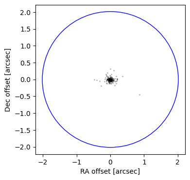

```python
fig, ax = plt.subplots(figsize=(4, 4))
circle = patches.Circle((0, 0), radius=0.00056*3600.0,
                        facecolor='None', edgecolor='blue')
ax.add_patch(circle)
ax.plot(results['ra_offset_arcsec'],
        results['dec_offset_arcsec'],
        'o', ms=2, mew=0, alpha=0.3, color='black')
ax.set_aspect(1)
plt.xlabel('RA offset [arcsec]')
plt.ylabel('Dec offset [arcsec]')
plt.tight_layout()
plt.show()
```

> **Figure 1:** The offset in RA and Dec, in arcseconds, of every source from the search coordinates. A 2" radius circule marks the search region.

Clean up.

```python
job.delete()
del query, results
```

#### 3.3.2. Joinable tables

The `Source` table can be joined to the `Visit` table on the column containing the unique visit identifier, `visit`.

The `Visit` table contains information about the observation, such as the MJD and band.

```python
query = "SELECT s.sourceId, s.visit, s.ra, s.dec, v.expMidptMJD, v.band " \
        "FROM dp2.Source AS s " \
        "JOIN dp2.Visit AS v ON s.visit = v.visit " \
        "WHERE CONTAINS(POINT('ICRS', s.ra, s.dec), " \
        "CIRCLE('ICRS', 53.128137, -28.103526, 0.00056)) = 1 " \
        "AND v.expMidptMJD > 60878.0 AND v.expMidptMJD < 60885.0"
job = tap_service.submit_job(query)
job.run()
job.wait(phases=['COMPLETED', 'ERROR'])
print('Job phase is', job.phase)
if job.phase == 'ERROR':
    job.raise_if_error()
```

```
Job phase is COMPLETED
```

Fetch the results as an `astropy` table.

```python
assert job.phase == 'COMPLETED'
results = job.fetch_result().to_table()
print(len(results))
```

```
32
```

Similar to Figure 1, plot the RA and Dec offsets of every source from the search coordinates, in arcseconds.

```python
cos_dec = np.cos(np.deg2rad(28.103526))
results['ra_offset_arcsec'] = (results['ra'] - 53.128137) * 3600.0 * cos_dec
results['dec_offset_arcsec'] = (results['dec'] + 28.103526) * 3600.0
```

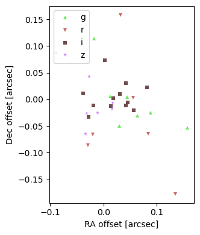

```python
fig, ax = plt.subplots(figsize=(4, 4))
for filt in filter_names:
    fx = np.where(results['band'] == filt)[0]
    if len(fx) > 0:
        ax.plot(results['ra_offset_arcsec'][fx],
                results['dec_offset_arcsec'][fx],
                filter_symbols[filt], ms=5, mew=0, alpha=0.7,
                color=filter_colors[filt], label=filt)
ax.set_aspect(1)
plt.xlabel('RA offset [arcsec]')
plt.ylabel('Dec offset [arcsec]')
plt.legend(loc='upper left')
plt.tight_layout()
plt.show()
```

Clean up.

```python
job.delete()
del query, results
```

### 3.4. Butler

TAP is the recommended way to access the source table, but the Butler is a convenient way to retrieve all the sources in a given visit.

Show that the dimensions for the `source` table are the filter, instrument, observation date, and visit, and that only instrument and visit are required.

```python
butler.get_dataset_type('source')
```

```
DatasetType('source', {band, instrument, day_obs, physical_filter, visit}, ArrowAstropy)
```

```python
butler.get_dataset_type('source').dimensions.required
```

```
{instrument, visit}
```

#### 3.4.1. Demo query

**Include spatial constraints:** The Butler `source` table contents are stored and retrieved by individual visit.

```python
ra = 53.13
dec = -28.10
time1 = Time(60878.0, format="mjd", scale="tai")
time2 = Time(60879.0, format="mjd", scale="tai")
timespan = Timespan(time1, time2)

refs = butler.query_datasets("source",
                             where="visit.timespan OVERLAPS :timespan AND \
                             visit_detector_region.region OVERLAPS POINT(:ra, :dec)",
                             bind={"timespan": timespan,
                                   "ra": ra, "dec": dec})
print(len(refs))
```

```
12
```

When using the Butler, `source` table data is returned by visit (by dataset reference).

Print the `dataId` of the first element of the `refs`.

```python
print(refs[0].dataId)
```

```
{instrument: 'LSSTCam', visit: 2025072100524, band: 'g', day_obs: 20250721, physical_filter: 'g_6'}
```

Define the columns to retrieve.

```python
col_list = ['sourceId', 'ra', 'dec', 'psfFlux', 'psfFluxErr']
```

Get the data from the Butler.

```python
results = butler.get(refs[0],
                     parameters={'columns': col_list})
print(len(results))
```

```
261409
```

Option to display the results.

```python
# results
```

Constrain the results to sources with magnitudes between 22 and 23 mag.

```python
tx = np.where((results['psfFlux'] > 2290.0)
              & (results['psfFlux'] <= 5760.0))[0]
print(len(tx))
```

```
48749
```

Plot the sky coordinates and `psfFlux` for the subset of objects.

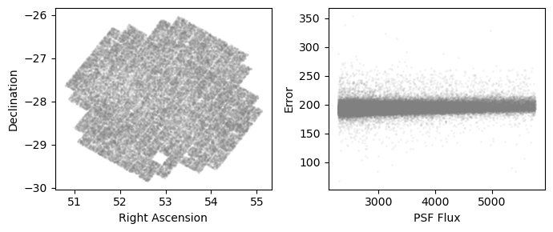

```python
fig, (ax1, ax2) = plt.subplots(1, 2, figsize=(7, 3))
ax1.plot(results['ra'][tx], results['dec'][tx],
         'o', ms=2, mew=0, alpha=0.1, color='grey')
ax1.set_xlabel('Right Ascension')
ax1.set_ylabel('Declination')
ax2.plot(results['psfFlux'][tx], results['psfFluxErr'][tx],
         'o', ms=2, mew=0, alpha=0.1, color='grey')
ax2.set_xlabel('PSF Flux')
ax2.set_ylabel('Error')
plt.tight_layout()
plt.show()
```

> **Figure 3:** At left, the RA vs. Dec of retrieved sources as grey points. At right, the PSF flux vs. its uncertainty.

```python
del ra, dec, time1, time2, timespan
del refs, col_list, results, tx
```